# EDA

Sravani Neelapala

09-06-2023

## R Markdown

```r
library(tidyverse)
  df <- Orange
   dim(df)
```

```
## [1] 35  3
```

```r
   head(df, 35)
```

```
##    Tree  age circumference
## 1     1  118            30
## 2     1  484            58
## 3     1  664            87
## 4     1 1004           115
## 5     1 1231           120
## 6     1 1372           142
## 7     1 1582           145
## 8     2  118            33
## 9     2  484            69
## 10    2  664           111
## 11    2 1004           156
## 12    2 1231           172
## 13    2 1372           203
## 14    2 1582           203
```

[output cut: 21 more lines]

```r
   summary(df)
```

```
##  Tree       age         circumference
##  3:7   Min.   : 118.0   Min.   : 30.0
##  1:7   1st Qu.: 484.0   1st Qu.: 65.5
##  5:7   Median :1004.0   Median :115.0
##  2:7   Mean   : 922.1   Mean   :115.9
##  4:7   3rd Qu.:1372.0   3rd Qu.:161.5
##        Max.   :1582.0   Max.   :214.0
```

```r
   Orange %>%
     count(Tree) %>%
     group_by(Tree) %>%
     knitr :: kable(format = "html")
```

| Tree | n |
| --- | --- |
| 3 | 7 |
| 1 | 7 |
| 5 | 7 |
| 2 | 7 |
| 4 | 7 |

```r
mode <- function(x,na.rm = TRUE){
  which.max(tabulate(x))
}

Orange %>%
  summarise(mean = mean(age, na.rm = TRUE),
             median = median(age, na.rm = TRUE),
             mode = mode(age,na.rm = TRUE),
             var = var(age, na.rm = TRUE),
             sd = sd(age, na.rm = TRUE))
```

```
##       mean median mode      var       sd
## 1 922.1429   1004  118 241930.7 491.8645
```

```r
range(Orange$age)
```

```
## [1]  118 1582
```

```r
 max(Orange$age) - min(Orange$age)
```

```
## [1] 1464
```

```r
mode <- function(x, na.rm = TRUE){
  which.max(tabulate(x))
}

Orange %>%
  summarise(mean = mean(circumference, na.rm = TRUE),
            median = median(circumference,na.rm = TRUE),
            mode = mode(circumference, na.rm = TRUE),
            var = var(circumference, na.rm = TRUE),
            sd = sd(circumference, na.rm = TRUE))
```

```
##       mean median mode      var       sd
## 1 115.8571    115   30 3304.891 57.48818
```

```r
range(Orange$circumference)
```

```
## [1]  30 214
```

```r
 max(Orange$circumference) - min(Orange$circumference)
```

```
## [1] 184
```

```r
mode <- function(x,na.rm = TRUE){
  which.max(tabulate(x))
}

Orange %>%
  group_by(Tree) %>%
  summarise(mean = mean(circumference, na.rm = TRUE),
            median = median(circumference, na.rm = TRUE),
            mode = mode(circumference, na.rm = TRUE),
            var = var(circumference, na.rm = TRUE),
            sd = sd(circumference, na.rm = TRUE))
```

```
## # A tibble: 5 × 6
##   Tree   mean median  mode   var    sd
##   <ord> <dbl>  <dbl> <int> <dbl> <dbl>
## 1 3      94      108    30 1847.  43.0
## 2 1      99.6    115    30 1874.  43.3
## 3 5     111.     125    30 3464.  58.9
## 4 2     135.     156   203 4399.  66.3
## 5 4     139.     167    32 5169.  71.9
```

Orange data frame. It has 35 observations and 3 variables.

There are two numeric variables “age” and “circumference”.

There is one categorical variable “Tree”.

There are no missing values in Orange data set.

There are no duplicate rows.

Tree: An ordered factor indicating the tree on which the measurement is made. The ordering is according to increasing maximum diameter.

Age: A numeric vector giving the age of the tree (days since 1968/12/31)

Circumference: A numeric vector of trunk circumferences (mm). This is probably “circumference at breast height”, a standard measurement in forestry.

There is a linear relation between age and circumference.As age increases the circumference of the tree also increases.

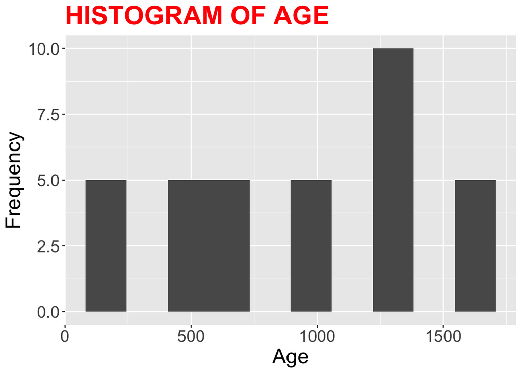

```r
ggplot(data = Orange) +
   geom_histogram(mapping = aes(x = age), bins = 10) +
   labs(title = "HISTOGRAM OF AGE", x = "Age", y  = "Frequency") +
   theme(plot.title = element_text(color = "red", size = 25, face = "bold")) +
   theme(text = element_text(size = 20))
```

** The histogram graph shows a left-skewed distribution because most of the values in the ‘age’ variable lie between 400 and 1300. **

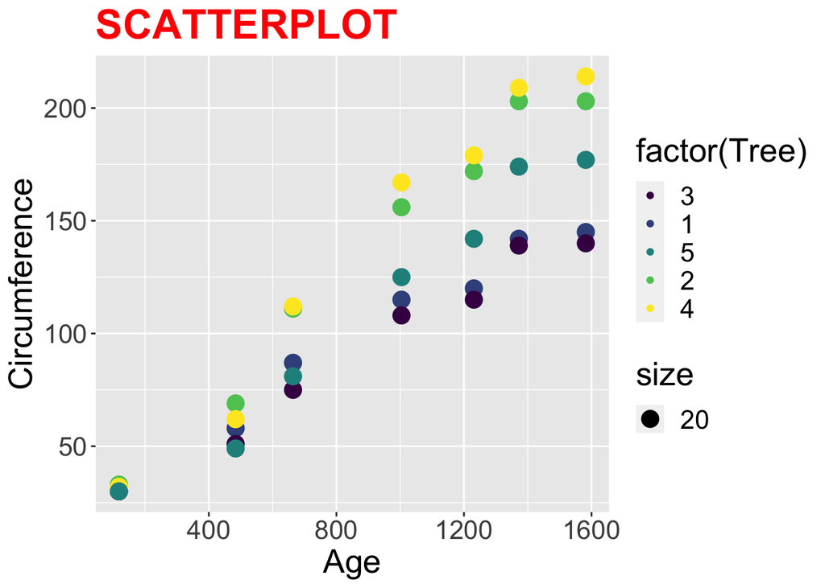

```r
ggplot(data = Orange) +
  geom_point(mapping = aes(x = age, y = circumference, color = factor(Tree), size = 20)) +
             labs(title = "SCATTERPLOT", x = "Age", y = "Circumference") +
             theme(plot.title = element_text(color = "red", size = 25, face = "bold")) +
             theme(text = element_text(size = 20))
```

** From the scatterplot graph, we can observe that as age increases, circumference also increases, with colors assigned to the points based on the tree.” **

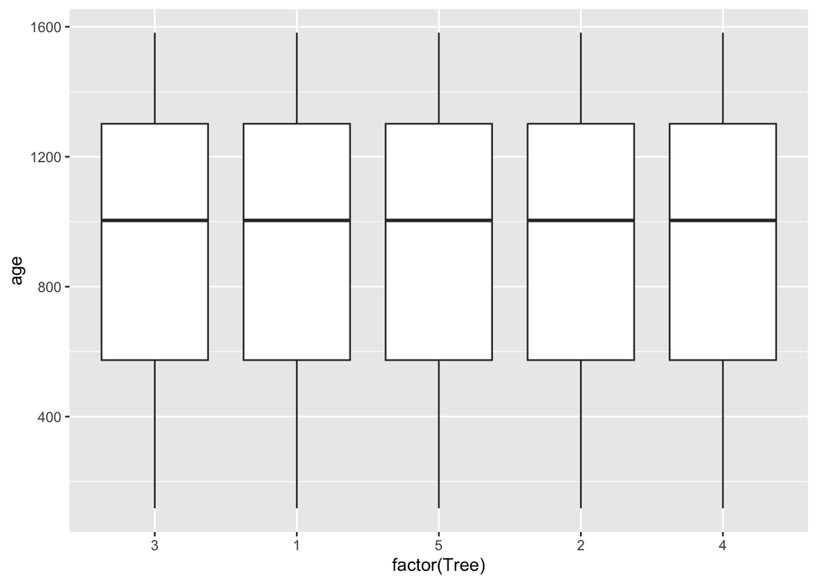

```r
ggplot(data = Orange) +
  geom_boxplot(mapping = aes(y = age, x = factor(Tree)))
```